# IE360_HW1

Berker Alp 2020402012

2024-03-23

```r
require(openxlsx) #library(openxlsx)
```

```r
require(ggplot2)
require(data.table)
require(skimr)
require(GGally)
require(ggcorrplot)
require(forecast)
require(dplyr)
options(repr.plot.width=25.4, repr.plot.height=17)
```

## Introduction

In this homework, it’s expected to pick 3 different categories of data from Central Bank of the Republic of Turkey(from EVDS System). Also, building three different models from these data sets for one main goal is required.

Main goal of the research is understanding “Are economic growth of Türkiye is increasing according to production capacity utilization, empty trucks enter to Türkiye and total workforce”. For that we use these independent data given below:

Empty truck entry to Türkiye(TP.UNDNAKLIYE.TBG.TOPLAM.ADET): Export products needs to taken by trucks from Türkiye. In other words, some trucks has no loads should come to Türkiye to load the export products of Türkiye to deliver other countries. During the report, it will be mentioned as truck

Industry capacity utilization of Türkiye(TP.TP.KKO.MA): It includes how much percent of the capacity of the industries used given month category. Amount of export defined how much product produced in other word how the industry is productive to supply exports.During the report, it will be mentioned as productivity

Workforce(TP.TIG03): It defines how many people employed. Amount of workforce might be effective to define production capacity of the industry. On the other hand it shows growth of the Türkiye ecomony along people

```r
#Excel of independent variables(we want to estimate)
data_link = "C:\\Users\\Berke\\Desktop\\main_data.xlsx"

importTR = read.xlsx(data_link)
str(importTR)
```

```
## 'data.frame':    131 obs. of  5 variables:
##  $ Tarih                        : chr  "2014-01" "2014-02" "2014-03" "2014-04" ...
##  $ TP.UNDNAKLIYE.TBG.TOPLAM.ADET: chr  "75532" "71733" "87857" "84838" ...
##  $ TP.IHRACATBEC.9999           : chr  "13056096.76" "13707842.6" "15431727.48" "14209640.81" ...
##  $ TP.KKO.MA                    : num  76.1 74.9 75.9 75.6 74.9 75.2 74.4 74.5 74.7 74.6 ...
##  $ TP.TIG03                     : num  25434 25357 25771 25758 25663 ...
```

From Google Trend these keyworks are searched “Türk İş Kurumu”: One of the government institution for work regulations and job seeking. “Kapıkule Sınır Kapısı”: One of the important border gate of Türkiye to Europe. “Üretim”: One of the keyword of published news about productivity.

```r
#csv of Google trends
uretim_link = "C:\\Users\\Berke\\Desktop\\uretim.csv"
sinir_link = "C:\\Users\\Berke\\Desktop\\sinir.csv"
istihtam_link = "C:\\Users\\Berke\\Desktop\\istihdam.csv"

uretim = read.csv(uretim_link,header=TRUE, stringsAsFactors=FALSE)
sinir = read.csv(sinir_link,header=TRUE, stringsAsFactors=FALSE)
istihtam = read.csv(istihtam_link,header=TRUE, stringsAsFactors=FALSE)
head(uretim)
```

```
##        Ay Uretim
## 1 2004-01     79
## 2 2004-02     73
## 3 2004-03     75
## 4 2004-04    100
## 5 2004-05     90
## 6 2004-06     61
```

```r
head(sinir)
```

```
##        Ay Kapikule.Sinir.Kapisi
## 1 2004-01                     0
## 2 2004-02                     0
## 3 2004-03                     0
## 4 2004-04                     0
## 5 2004-05                     0
## 6 2004-06                     0
```

```r
head(istihtam)
```

```
##        Ay Turk.Is.Kurumu
## 1 2004-01             10
## 2 2004-02             10
## 3 2004-03              8
## 4 2004-04             11
## 5 2004-05              9
## 6 2004-06              8
```

```r
str(uretim)
```

```
## 'data.frame':    243 obs. of  2 variables:
##  $ Ay    : chr  "2004-01" "2004-02" "2004-03" "2004-04" ...
##  $ Uretim: int  79 73 75 100 90 61 63 44 63 68 ...
```

```r
str(sinir)
```

```
## 'data.frame':    243 obs. of  2 variables:
##  $ Ay                   : chr  "2004-01" "2004-02" "2004-03" "2004-04" ...
##  $ Kapikule.Sinir.Kapisi: int  0 0 0 0 0 0 0 0 0 0 ...
```

```r
str(istihtam)
```

```
## 'data.frame':    243 obs. of  2 variables:
##  $ Ay            : chr  "2004-01" "2004-02" "2004-03" "2004-04" ...
##  $ Turk.Is.Kurumu: int  10 10 8 11 9 8 16 25 47 38 ...
```

Convert data types of importTR

```r
require(lubridate)
importTR$Tarih <- ym(importTR$Tarih)
importTR$TP.UNDNAKLIYE.TBG.TOPLAM.ADET <- as.numeric(importTR$TP.UNDNAKLIYE.TBG.TOPLAM.ADET)
importTR$TP.IHRACATBEC.9999 <- as.numeric(importTR$TP.IHRACATBEC.9999)
uretim$Ay <-ym(uretim$Ay)

sinir$Ay <- ym(sinir$Ay)

istihtam$Ay <- ym(istihtam$Ay)

head(importTR)
```

```
##        Tarih TP.UNDNAKLIYE.TBG.TOPLAM.ADET TP.IHRACATBEC.9999 TP.KKO.MA
## 1 2014-01-01                         75532           13056097      76.1
## 2 2014-02-01                         71733           13707843      74.9
## 3 2014-03-01                         87857           15431727      75.9
## 4 2014-04-01                         84838           14209641      75.6
## 5 2014-05-01                         85717           14460399      74.9
## 6 2014-06-01                         76983           13554949      75.2
##   TP.TIG03
## 1    25434
## 2    25357
## 3    25771
## 4    25758
## 5    25663
## 6    26098
```

```r
tail(importTR)
```

```
##     Tarih TP.UNDNAKLIYE.TBG.TOPLAM.ADET TP.IHRACATBEC.9999 TP.KKO.MA TP.TIG03
## 126  <NA>                            NA                 NA        NA       NA
## 127  <NA>                            NA                 NA        NA       NA
## 128  <NA>                            NA                 NA        NA       NA
## 129  <NA>                            NA                 NA        NA       NA
## 130  <NA>                            NA                 NA        NA       NA
## 131  <NA>                            NA                 NA        NA       NA
```

```r
# numerical statistics of the data
summary_data=skim(importTR)
print(summary_data)
```

```
## ── Data Summary ────────────────────────
##                            Values
## Name                       importTR
## Number of rows             131
## Number of columns          5
## _______________________
## Column type frequency:
##   Date                     1
##   numeric                  4
## ________________________
## Group variables            None
##
## ── Variable type: Date ─────────────────────────────────────────────────────────
##   skim_variable n_missing complete_rate min        max        median
## 1 Tarih                22         0.832 2014-01-01 2023-01-01 2018-07-01
##   n_unique
## 1      109
##
## ── Variable type: numeric ──────────────────────────────────────────────────────
##   skim_variable                 n_missing complete_rate       mean         sd
## 1 TP.UNDNAKLIYE.TBG.TOPLAM.ADET        22         0.832    77051.    10382.
## 2 TP.IHRACATBEC.9999                   22         0.832 15207424.  3204657.
## 3 TP.KKO.MA                            22         0.832       76.2       2.66
## 4 TP.TIG03                             22         0.832    27859.     1521.
##          p0        p25        p50        p75       p100 hist
## 1   48397      70262      76314      84856      99315   ▁▃▇▅▃
## 2 8978291   13179496.  14376629.  16386878.  23359482   ▂▇▃▂▂
## 3      61.9       75.4       76.6       77.7       79.5 ▁▁▁▃▇
## 4   25098      26857      27895      28691      31710   ▅▆▇▂▂
```

We have know last 22 rows are empty so we will drop them.

```r
importTR <- na.omit(importTR)
summary_data=skim(importTR)
print(summary_data)
```

```
## ── Data Summary ────────────────────────
##                            Values
## Name                       importTR
## Number of rows             109
## Number of columns          5
## _______________________
## Column type frequency:
##   Date                     1
##   numeric                  4
## ________________________
## Group variables            None
##
## ── Variable type: Date ─────────────────────────────────────────────────────────
##   skim_variable n_missing complete_rate min        max        median
## 1 Tarih                 0             1 2014-01-01 2023-01-01 2018-07-01
##   n_unique
## 1      109
##
## ── Variable type: numeric ──────────────────────────────────────────────────────
##   skim_variable                 n_missing complete_rate       mean         sd
## 1 TP.UNDNAKLIYE.TBG.TOPLAM.ADET         0             1    77051.    10382.
## 2 TP.IHRACATBEC.9999                    0             1 15207424.  3204657.
## 3 TP.KKO.MA                             0             1       76.2       2.66
## 4 TP.TIG03                              0             1    27859.     1521.
##          p0        p25        p50        p75       p100 hist
## 1   48397      70262      76314      84856      99315   ▁▃▇▅▃
## 2 8978291   13179496.  14376629.  16386878.  23359482   ▂▇▃▂▂
## 3      61.9       75.4       76.6       77.7       79.5 ▁▁▁▃▇
## 4   25098      26857      27895      28691      31710   ▅▆▇▂▂
```

```r
tail(importTR)
```

```
##          Tarih TP.UNDNAKLIYE.TBG.TOPLAM.ADET TP.IHRACATBEC.9999 TP.KKO.MA
## 104 2022-08-01                         88539           21275850      76.6
## 105 2022-09-01                         92843           22596774      77.3
## 106 2022-10-01                         93603           21300785      76.6
## 107 2022-11-01                         92206           21871039      75.9
## 108 2022-12-01                         95991           22898749      76.4
## 109 2023-01-01                         77664           19311522      75.8
##     TP.TIG03
## 104    31007
## 105    30920
## 106    31093
## 107    31502
## 108    31340
## 109    31710
```

Join of google trend excels

```r
require(tidyverse)
google_data <- list(uretim,sinir,istihtam)
google <- google_data %>% reduce(full_join, by='Ay')
head(google)
```

```
##           Ay Uretim Kapikule.Sinir.Kapisi Turk.Is.Kurumu
## 1 2004-01-01     79                     0             10
## 2 2004-02-01     73                     0             10
## 3 2004-03-01     75                     0              8
## 4 2004-04-01    100                     0             11
## 5 2004-05-01     90                     0              9
## 6 2004-06-01     61                     0              8
```

Join of Google trend data to predicted parameters

```r
colnames(google)[colnames(google) == 'Ay'] <- 'Tarih'
data <- list(importTR,google)
importTR <- data %>% reduce(inner_join, by ='Tarih')
head(importTR)
```

```
##        Tarih TP.UNDNAKLIYE.TBG.TOPLAM.ADET TP.IHRACATBEC.9999 TP.KKO.MA
## 1 2014-01-01                         75532           13056097      76.1
## 2 2014-02-01                         71733           13707843      74.9
## 3 2014-03-01                         87857           15431727      75.9
## 4 2014-04-01                         84838           14209641      75.6
## 5 2014-05-01                         85717           14460399      74.9
## 6 2014-06-01                         76983           13554949      75.2
##   TP.TIG03 Uretim Kapikule.Sinir.Kapisi Turk.Is.Kurumu
## 1    25434     20                     2             31
## 2    25357     19                     5             32
## 3    25771     19                     3             30
## 4    25758     21                     3             30
## 5    25663     19                     2             31
## 6    26098     18                     2             29
```

Predictor variables data TP.TSANAYMT2021.Y1: Industry production index. It will be used for productivity and truck. Productivity and Truck has some kind of relationship even though it is not strong. If product is produced it also will be transferred. Because of that production index related to two of them. TP.KTF17: Rate of commercial credit. It is especially for productivity because lower rate may cause more investment on productivity. TP.AC2.TOP.A: How many company opened TP.KAP2.TOP.A: How many company closed. Closed and opened company number defines how many people employed so they are key predictor for workforce TP.DK.USD.A.YTL: Turkish lira American Dollar currency. It will be used for truck since it effects its costs.

```r
sub_link = "C:\\Users\\Berke\\Desktop\\sub_data.xlsx"
sub_data = read.xlsx(sub_link)
str(sub_data)
```

```
## 'data.frame':    157 obs. of  6 variables:
##  $ Tarih             : chr  "2014-01" "2014-02" "2014-03" "2014-04" ...
##  $ TP.TSANAYMT2021.Y1: chr  "69.9536329182" "69.358860456399995" "69.448289278800004" "68.848422692699998" ...
##  $ TP.KTF17          : chr  "13.247999999999999" "15.45" "16.0625" "15.0625" ...
##  $ TP.AC2.TOP.A      : num  5916 4771 5026 4959 4768 ...
##  $ TP.KAP2.TOP.A     : num  2892 1181 1073 937 968 ...
##  $ TP.DK.USD.A.YTL   : num  2.22 2.21 2.22 2.13 2.09 ...
```

```r
sub_data$Tarih = ym(sub_data$Tarih)
sub_data$TP.TSANAYMT2021.Y1 = as.numeric(sub_data$TP.TSANAYMT2021.Y1)
sub_data$TP.KTF17 = as.numeric(sub_data$TP.KTF17)
head(sub_data)
```

```
##        Tarih TP.TSANAYMT2021.Y1 TP.KTF17 TP.AC2.TOP.A TP.KAP2.TOP.A
## 1 2014-01-01           69.95363  13.2480         5916          2892
## 2 2014-02-01           69.35886  15.4500         4771          1181
## 3 2014-03-01           69.44829  16.0625         5026          1073
## 4 2014-04-01           68.84842  15.0625         4959           937
## 5 2014-05-01           67.90698  14.1520         4768           968
## 6 2014-06-01           69.28235  13.5025         4851          1120
##   TP.DK.USD.A.YTL
## 1        2.216836
## 2        2.212760
## 3        2.217795
## 4        2.127471
## 5        2.090805
## 6        2.115724
```

```r
list <- list(importTR,sub_data)
importTR <- list %>% reduce(inner_join, by ='Tarih')
head(importTR)
```

```
##        Tarih TP.UNDNAKLIYE.TBG.TOPLAM.ADET TP.IHRACATBEC.9999 TP.KKO.MA
## 1 2014-01-01                         75532           13056097      76.1
## 2 2014-02-01                         71733           13707843      74.9
## 3 2014-03-01                         87857           15431727      75.9
## 4 2014-04-01                         84838           14209641      75.6
## 5 2014-05-01                         85717           14460399      74.9
## 6 2014-06-01                         76983           13554949      75.2
##   TP.TIG03 Uretim Kapikule.Sinir.Kapisi Turk.Is.Kurumu TP.TSANAYMT2021.Y1
## 1    25434     20                     2             31           69.95363
## 2    25357     19                     5             32           69.35886
## 3    25771     19                     3             30           69.44829
## 4    25758     21                     3             30           68.84842
## 5    25663     19                     2             31           67.90698
## 6    26098     18                     2             29           69.28235
##   TP.KTF17 TP.AC2.TOP.A TP.KAP2.TOP.A TP.DK.USD.A.YTL
## 1  13.2480         5916          2892        2.216836
## 2  15.4500         4771          1181        2.212760
## 3  16.0625         5026          1073        2.217795
## 4  15.0625         4959           937        2.127471
## 5  14.1520         4768           968        2.090805
## 6  13.5025         4851          1120        2.115724
```

We are setting sub data sets for the target variables with their predictor variables we like to find time series regression for them

```r
workforce <- data.frame(importTR$Tarih,importTR$TP.TIG03,importTR$Turk.Is.Kurumu,importTR$TP.AC2.TOP.A,importTR$TP.KAP2.TOP.A)
productivity <- data.frame(importTR$Tarih,importTR$TP.KKO.MA,importTR$Uretim,importTR$TP.KTF17,importTR$TP.TSANAYMT2021.Y1)
truck <- data.frame(importTR$Tarih,importTR$TP.UNDNAKLIYE.TBG.TOPLAM.ADET,importTR$Kapikule.Sinir.Kapisi,importTR$TP.TSANAYMT2021.Y1,importTR$TP.DK.USD.A.YTL)
variables <- data.frame(importTR$Tarih,importTR$TP.UNDNAKLIYE.TBG.TOPLAM.ADET,importTR$TP.KKO.MA,importTR$TP.TIG03)
```

```r
head(workforce)
```

```
##   importTR.Tarih importTR.TP.TIG03 importTR.Turk.Is.Kurumu
## 1     2014-01-01             25434                      31
## 2     2014-02-01             25357                      32
## 3     2014-03-01             25771                      30
## 4     2014-04-01             25758                      30
## 5     2014-05-01             25663                      31
## 6     2014-06-01             26098                      29
##   importTR.TP.AC2.TOP.A importTR.TP.KAP2.TOP.A
## 1                  5916                   2892
## 2                  4771                   1181
## 3                  5026                   1073
## 4                  4959                    937
## 5                  4768                    968
## 6                  4851                   1120
```

```r
head(productivity)
```

```
##   importTR.Tarih importTR.TP.KKO.MA importTR.Uretim importTR.TP.KTF17
## 1     2014-01-01               76.1              20           13.2480
## 2     2014-02-01               74.9              19           15.4500
## 3     2014-03-01               75.9              19           16.0625
## 4     2014-04-01               75.6              21           15.0625
## 5     2014-05-01               74.9              19           14.1520
## 6     2014-06-01               75.2              18           13.5025
##   importTR.TP.TSANAYMT2021.Y1
## 1                    69.95363
## 2                    69.35886
## 3                    69.44829
## 4                    68.84842
## 5                    67.90698
## 6                    69.28235
```

```r
head(truck)
```

```
##   importTR.Tarih importTR.TP.UNDNAKLIYE.TBG.TOPLAM.ADET
## 1     2014-01-01                                  75532
## 2     2014-02-01                                  71733
## 3     2014-03-01                                  87857
## 4     2014-04-01                                  84838
## 5     2014-05-01                                  85717
## 6     2014-06-01                                  76983
##   importTR.Kapikule.Sinir.Kapisi importTR.TP.TSANAYMT2021.Y1
## 1                              2                    69.95363
## 2                              5                    69.35886
## 3                              3                    69.44829
## 4                              3                    68.84842
## 5                              2                    67.90698
## 6                              2                    69.28235
##   importTR.TP.DK.USD.A.YTL
## 1                 2.216836
## 2                 2.212760
## 3                 2.217795
## 4                 2.127471
## 5                 2.090805
## 6                 2.115724
```

```r
head(variables)
```

```
##   importTR.Tarih importTR.TP.UNDNAKLIYE.TBG.TOPLAM.ADET importTR.TP.KKO.MA
## 1     2014-01-01                                  75532               76.1
## 2     2014-02-01                                  71733               74.9
## 3     2014-03-01                                  87857               75.9
## 4     2014-04-01                                  84838               75.6
## 5     2014-05-01                                  85717               74.9
## 6     2014-06-01                                  76983               75.2
##   importTR.TP.TIG03
## 1             25434
## 2             25357
## 3             25771
## 4             25758
## 5             25663
## 6             26098
```

From there can we see our target variables has no strong correlation. On the other hand workforce(TR.TIG03) has time dependent factors

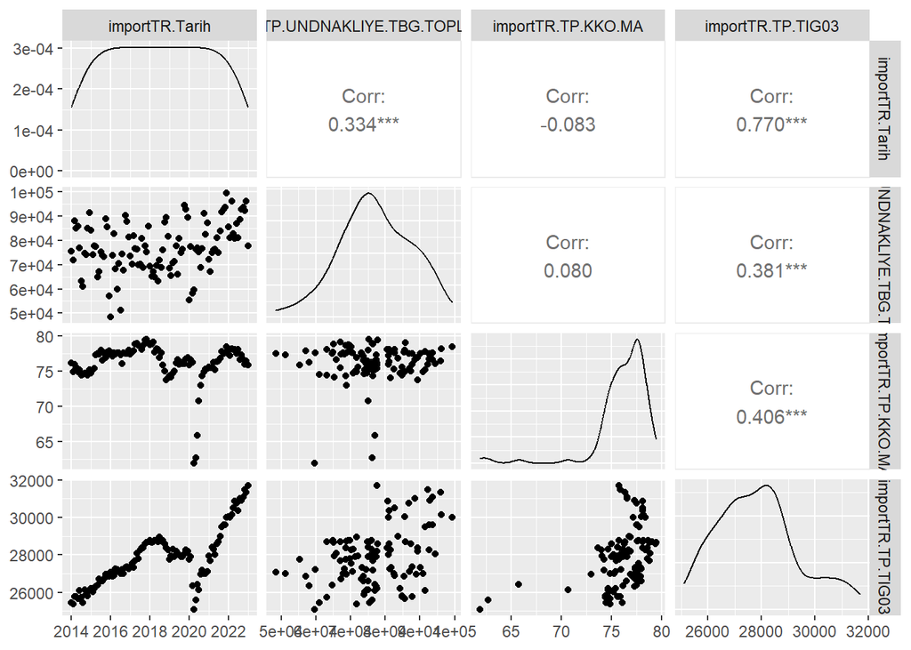

```r
ggpairs(variables)
```

Basic knowlegde about productivity

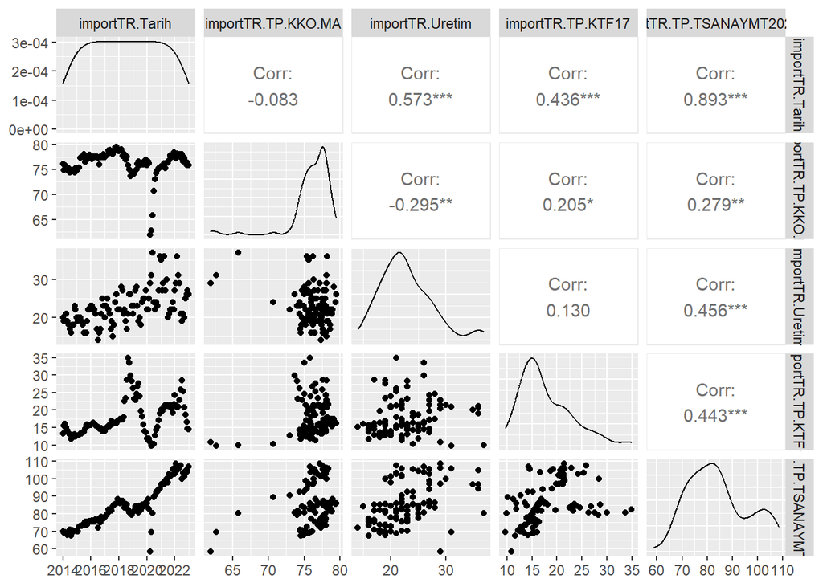

```r
ggpairs(productivity)
```

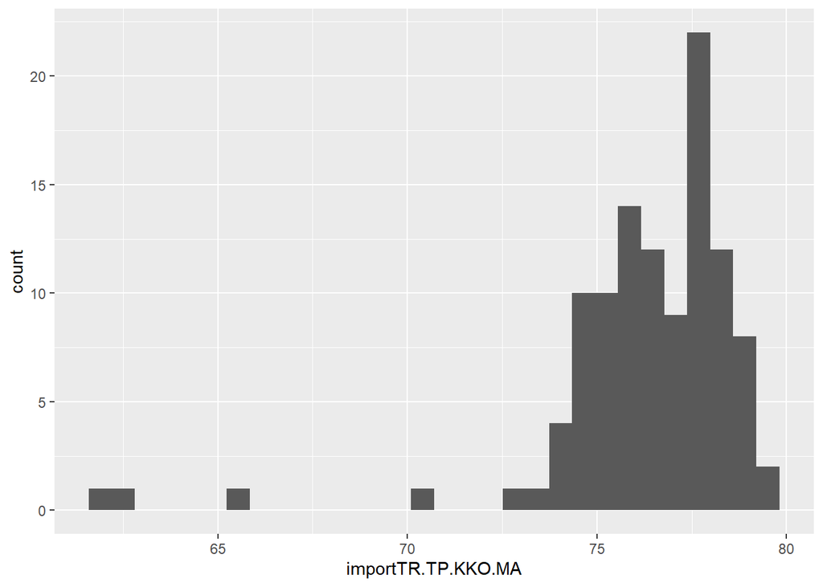

```r
ggplot(productivity, aes(x=importTR.TP.KKO.MA)) + geom_histogram()
```

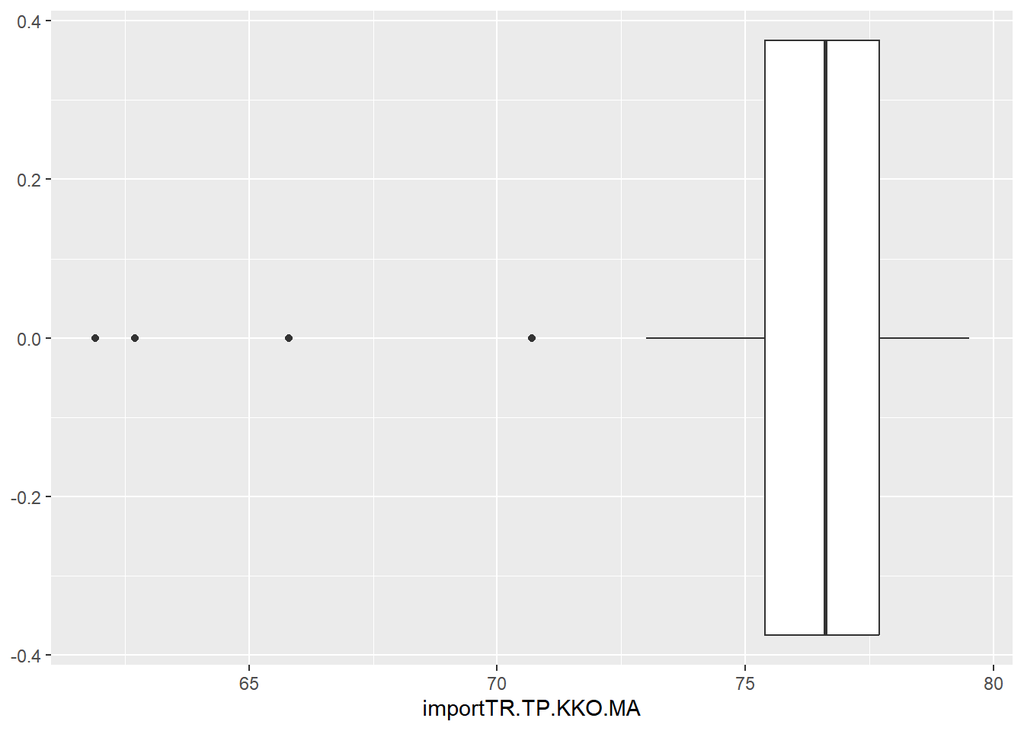

```r
ggplot(productivity, aes(x=importTR.TP.KKO.MA)) + geom_boxplot()
```

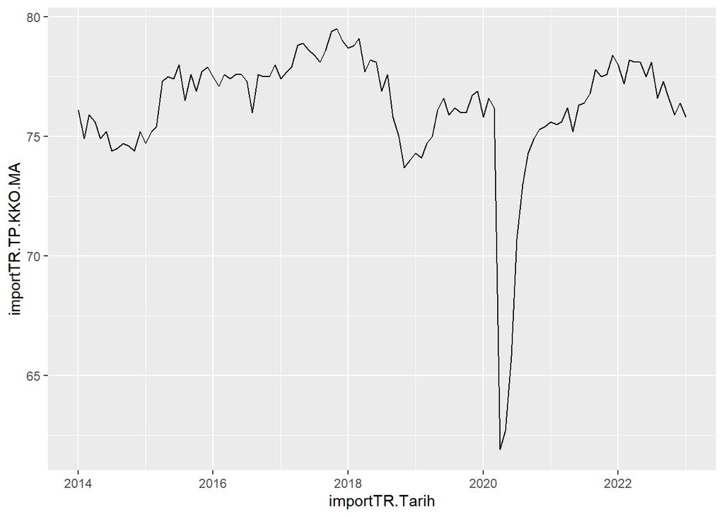

```r
ggplot(productivity,aes(x=importTR.Tarih,y=importTR.TP.KKO.MA,group=1)) +geom_line()
```

Line graphs of the predictors

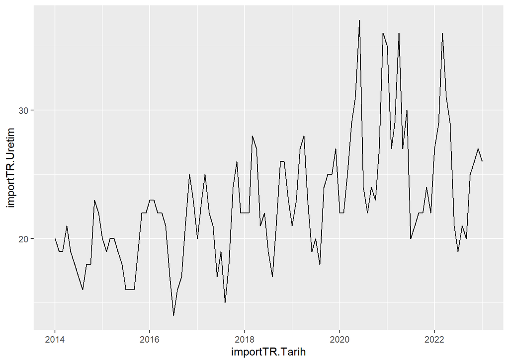

```r
ggplot(productivity,aes(x=importTR.Tarih,y=importTR.Uretim,group=1)) +geom_line()
```

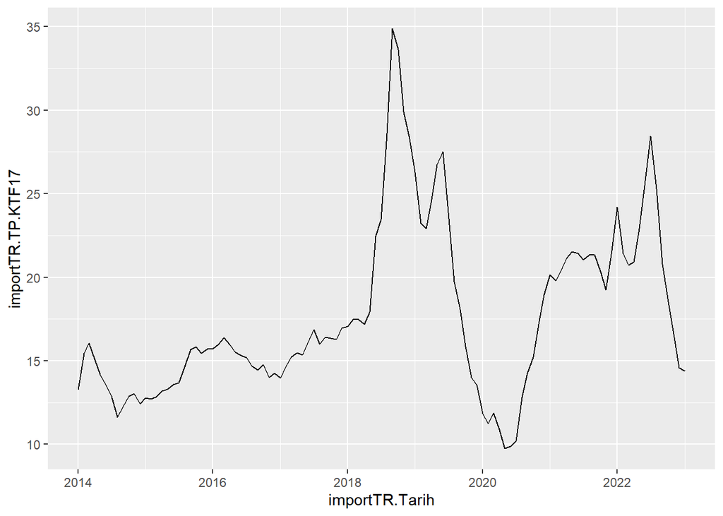

```r
ggplot(productivity,aes(x=importTR.Tarih,y=importTR.TP.KTF17,group=1)) +geom_line()
```

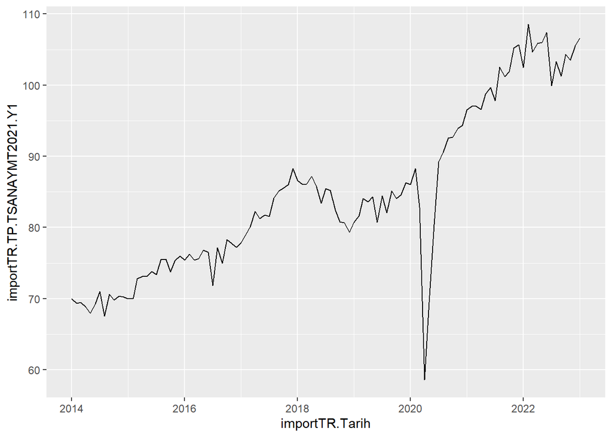

```r
ggplot(productivity,aes(x=importTR.Tarih,y=importTR.TP.TSANAYMT2021.Y1,group=1)) +geom_line()
```

We are checking autocorrelation of the series with 12 lag to understand effect of the months in the series. we can see first 6 lag are significant for productivity(importTR.TP.KKO.MA). We can say month sesaons are not effective but other seasons exists.

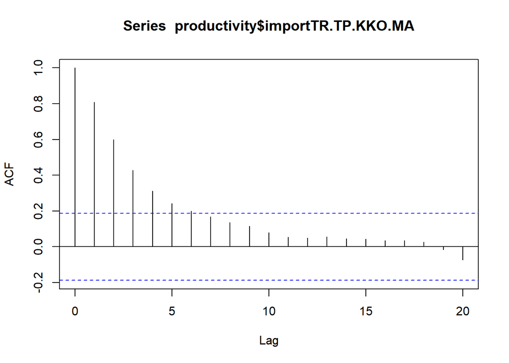

```r
acf(productivity$importTR.TP.KKO.MA)
```

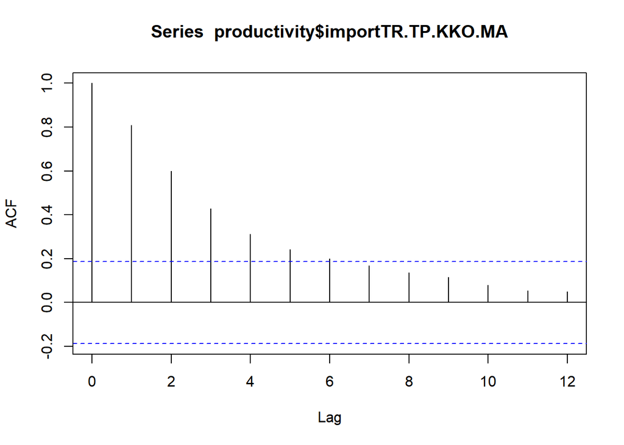

```r
acf(productivity$importTR.TP.KKO.MA,12)
```

Basic knowledge about workforce

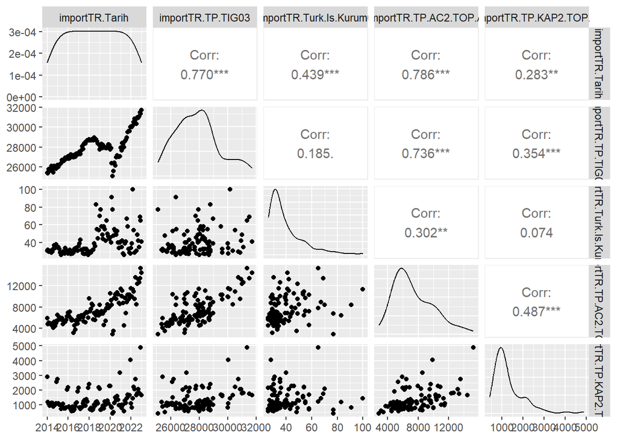

```r
ggpairs(workforce)
```

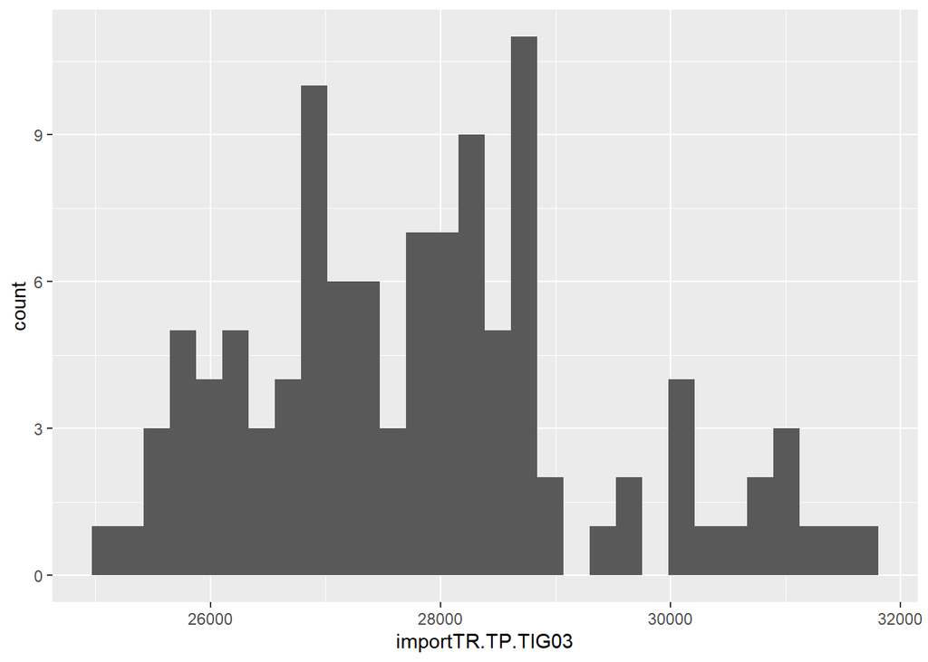

```r
ggplot(workforce, aes(x=importTR.TP.TIG03)) + geom_histogram()
```

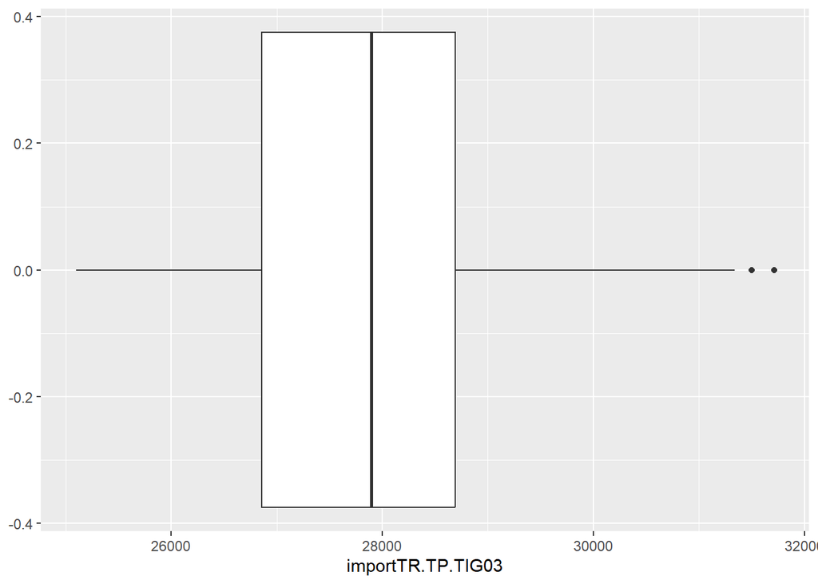

```r
ggplot(workforce, aes(x=importTR.TP.TIG03)) + geom_boxplot()
```

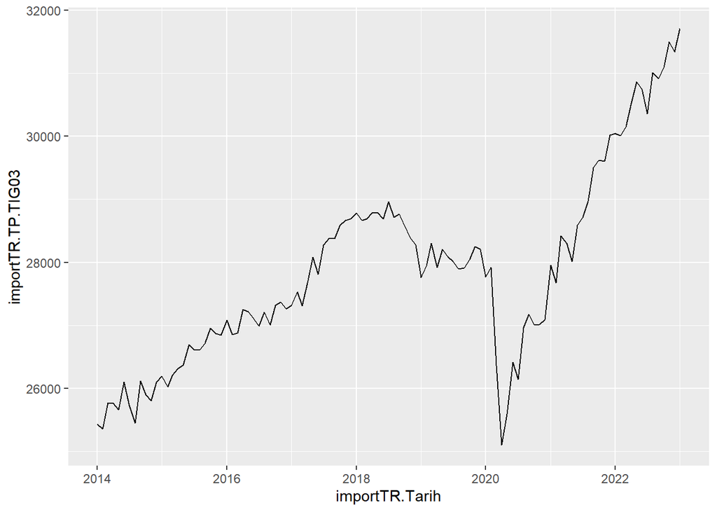

```r
ggplot(workforce,aes(x=importTR.Tarih,y=importTR.TP.TIG03,group=1)) +geom_line()
```

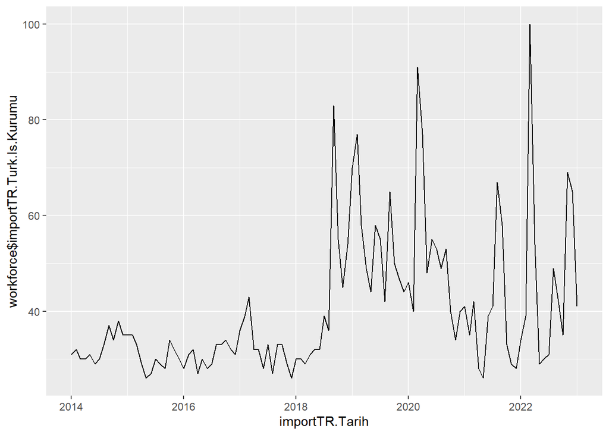

```r
ggplot(productivity,aes(x=importTR.Tarih,y=workforce$importTR.Turk.Is.Kurumu,group=1)) +geom_line()
```